# t-copula with t and two piece t marginals

[F. Javier Rubio](https://sites.google.com/site/fjavierrubio67/)

01/07/2017

## A real data example to illustrate how to fit a t-copula with t and two piece t marginals

The $t$-copula is defined as [1,2]
$$C_d^t({\bf u}\vert {\bf R},\nu) = \int_{-\infty}^{t^{-1}_{\nu}(u_1)}\cdots\int_{-\infty}^{t^{-1}_{\nu}(u_d)} \dfrac{\Gamma\left(\dfrac{\nu+d}{2}\right)}{\Gamma\left(\dfrac{\nu}{2}\right)\sqrt{(\pi\nu)^d\vert{\bf R}\vert}} \left(1+\dfrac{{\bf x}^{\top}{\bf R}^{-1}{\bf x}}{\nu}\right)^{-\frac{\nu+d}{2}} d{\bf x},$$
where ${\bf u}=(u_1,\dots,u_d)\in[0,1]^d$, ${\bf R}$ is a correlation matrix, and $t^{-1}_{\nu}$ denotes the quantile function associated to a Student-$t$ variate with $\nu>0$ degrees of freedom. The corresponding density function is given by [1]
$$c_d^t({\bf u}\vert {\bf R},\nu) = \dfrac{f_d(t^{-1}_{\nu}(u_1),\dots,t^{-1}_{\nu}(u_d)\vert {\bf 0},{\bf R},\nu)}{\prod_{j=1}^d f_1(t^{-1}_{\nu}(u_j))}.$$
Analogously to the multivariate $t$ distribution, the $t$-copula converges to the Normal copula for increasing values of the number of degrees of freedom. That is, $C_{\nu,d}^t\rightarrow C_d^N$ for $\nu\rightarrow\infty$.

Here, we consider a financial application of the t-copula where we model jointly the daily log-returns for the Swiss Market Index (SMI) and Swiss reinsurer (Swiss.Re). The data are available from the R package ‘ghyp’ and contain $n = 1769$ observations corresponding to the period January 2000 to January 2007. We consider two cases for the marginals: (i) student-t with $\nu_1,\nu_2$ degrees of freedom, and (2) two-piece student-t (see [1,3]). We fit these models using maximum likelihood estimation.

**References**

1. [Objective priors for the number of degrees of freedom of a multivariate t distribution and the t-copula](https://arxiv.org/abs/1701.05638)
2. [The t Copula and Related Copulas](http://www.jstor.org/stable/25472643)
3. [Inference in Two-Piece Location-Scale Models with Jeffreys Priors](http://projecteuclid.org/euclid.ba/1393251764)
4. [twopiece R package](http://rpubs.com/FJRubio/twopiece)
5. Copula (probability theory) on Wikipedia

```r
##############################################################################################
# Data from : ghyp package
##############################################################################################
rm(list=ls())
library(mnormt)
library(mvtnorm)
library(ghyp)
library(twopiece)
library(copula)
library(fMultivar)
# The SMI stocks data:  "SMI"  vs    "Swiss.Re"
data(smi.stocks)
Y = as.matrix(smi.stocks[ , c(1, 6)])
colnames(smi.stocks[ , c(1, 6)])
```

```
## [1] "SMI"      "Swiss.Re"
```

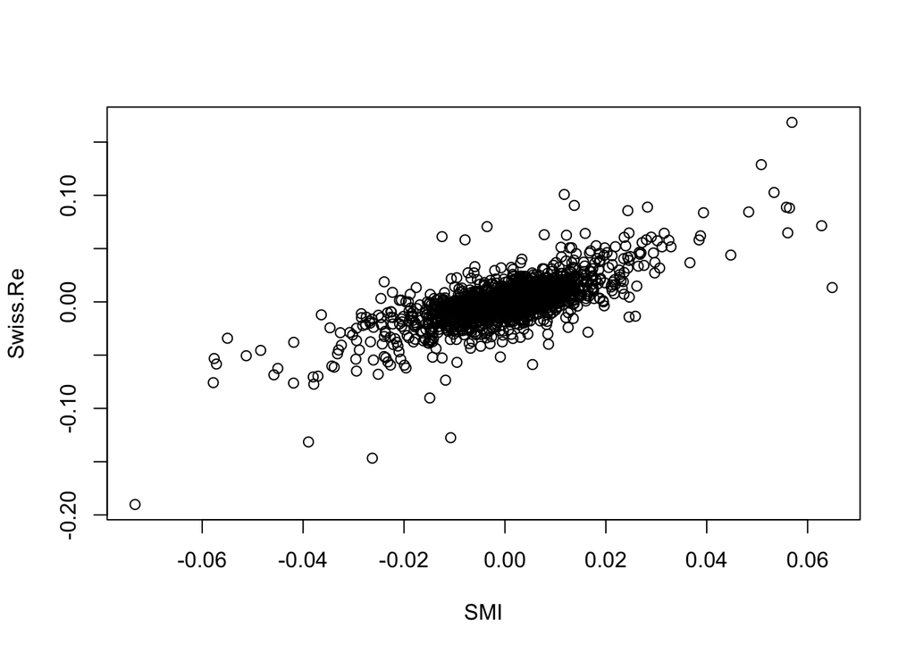

```r
plot(Y)
```

```r
cor(Y)
```

```
##                SMI  Swiss.Re
## SMI      1.0000000 0.7236403
## Swiss.Re 0.7236403 1.0000000
```

```r
##############################################################################################
# MLE: bivariate t-copula with two-piece t marginals
##############################################################################################

# log likelihood function
loglik = function(par){
  mu = par[1:2]; sigma = par[3:4]; nu1 = par[5]; nu2 = par[6]; rho = par[7]; nut = par[8]; epsilon = par[9:10];
  if(par[3]>0 & par[4]>0 & par[5]>0 & par[6]>0 & par[8]>0 & abs(par[7])<1 & abs(par[9])<1 & abs(par[10])<1){
    t.cop = tCopula(rho,dim=2,df=nut)
    prob.t =cbind(ptp4(Y[,1]-mu[1],0,sigma[1],epsilon[1],nu1,param="eps",FUN=pt),ptp4(Y[,2]-mu[2],0,sigma[2],epsilon[2],nu2,param="eps",FUN=pt))
    val.cop = -sum(dCopula(prob.t, copula=t.cop, log=TRUE))
    val.marg1 = -sum( dtp4(Y[,1]-mu[1],0,sigma[1],epsilon[1],nu1,param="eps",FUN=dt,log=T) )
    val.marg2 = -sum( dtp4(Y[,2]-mu[2],0,sigma[2],epsilon[2],nu2,param="eps",FUN=dt,log=T) )
    return(val.cop + val.marg1 + val.marg2)
  }
  else return(Inf)
}

start = c(0,0,0.01,0.01,3,2.5,0.7,4,0,0)

# Optimisation step and AIC
OPT = nlminb(start,loglik,control=list(maxit=10000))
OPT
```

```
## $par
##  [1]  0.0012022294 -0.0001405247  0.0079397968  0.0112400722  3.4501143941
##  [6]  2.5346718465  0.6936747155  3.8914966701  0.0745037927  0.0123678105
##
## $objective
## [1] -10809.4
##
## $convergence
## [1] 0
##
## $iterations
## [1] 76
##
## $evaluations
## function gradient
##      141      992
##
## $message
## [1] "relative convergence (4)"
```

```r
AIC <- 2*OPT$objective + 2*length(start)

##############################################################################################
# MLE: bivariate t-copula with t marginals
##############################################################################################
# log likelihood function
loglik0 = function(par){
  mu = par[1:2]; sigma = par[3:4]; nu1 = par[5]; nu2 = par[6]; rho = par[7]; nut = par[8];
  if(par[3]>0 & par[4]>0 & par[5]>0 & par[6]>0 & par[8]>0 & abs(par[7])<1){
    t.cop = tCopula(rho,dim=2,df=nut)
    prob.t = cbind(pt((Y[,1]-mu[1])/sigma[1],df=nu1),pt((Y[,2]-mu[2])/sigma[2],df=nu2))
    val.cop = -sum(dCopula(prob.t, copula=t.cop, log=TRUE))
    val.marg1 = -sum( dt((Y[,1]-mu[1])/sigma[1],df=nu1,log=T) - log(sigma[1]) )
    val.marg2 = -sum( dt((Y[,2]-mu[2])/sigma[2],df=nu2,log=T) - log(sigma[2]) )
    return(val.cop + val.marg1 + val.marg2)
  }
  else return(Inf)
}

# Initial point
start0 = c(0,0,0.01,0.01,3,2,0,5)

# Optimisation step and AIC
OPT0 = nlminb(start0,loglik0,control=list(maxit=10000))
OPT0
```

```
## $par
## [1]  0.0003159914 -0.0002179792  0.0079439912  0.0112284454  3.4552762270
## [6]  2.5221262260  0.6930807588  3.9317265523
##
## $objective
## [1] -10805.26
##
## $convergence
## [1] 0
##
## $iterations
## [1] 62
##
## $evaluations
## function gradient
##      105      565
##
## $message
## [1] "relative convergence (4)"
```

```r
AIC0 <- 2*OPT0$objective + 2*length(start0)

# Comparison: the model with two-piece t marginals is slightly better
c(AIC,AIC0)
```

```
## [1] -21598.79 -21594.51
```

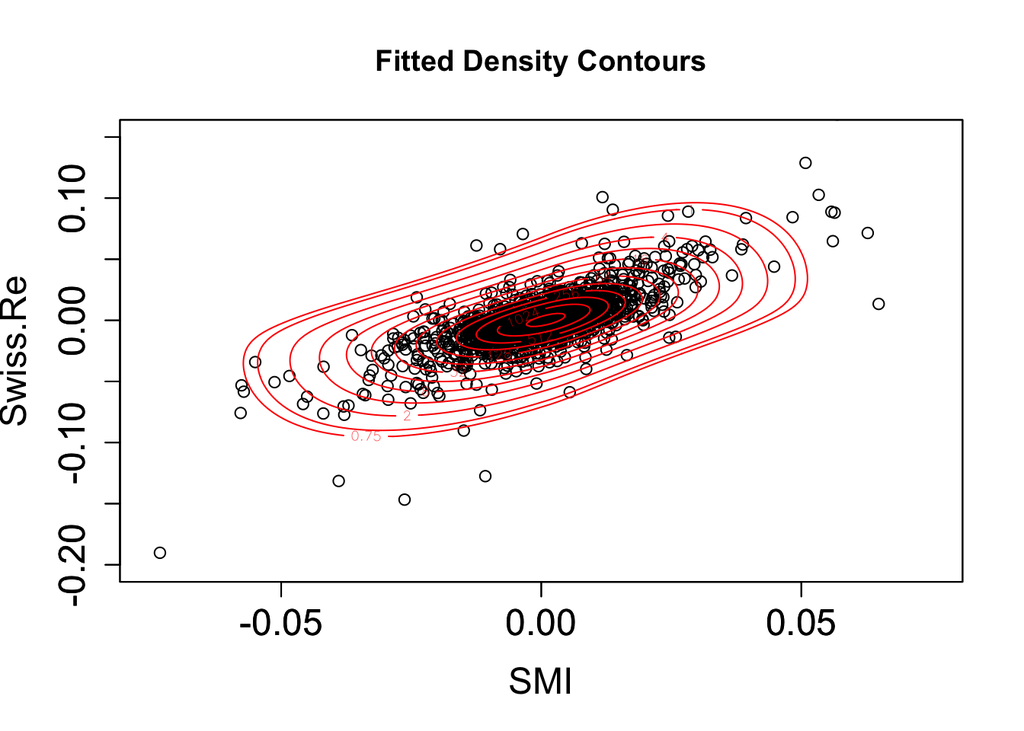

```r
#####################################################################################################################################################
# Contour plots
#####################################################################################################################################################
# Fitted density
pred.den <- function(x){
    mu = OPT$par[1:2]
    sigma = OPT$par[3:4]
    rho = OPT$par[7]
    nu = OPT$par[8]
    nu1 = OPT$par[5]
    nu2 = OPT$par[6]
    epsilon = OPT$par[9:10]
    t.cop = tCopula(rho,dim=2,df=nu)
    prob.t =cbind(ptp4(x[1]-mu[1],0,sigma[1],epsilon[1],nu1,param="eps",FUN=pt),ptp4(x[2]-mu[2],0,sigma[2],epsilon[2],nu2,param="eps",FUN=pt))
    var = dCopula(prob.t, copula=t.cop, log=FALSE)*dtp4(x[1]-mu[1],0,sigma[1],epsilon[1],nu1,param="eps",FUN=dt)*dtp4(x[2]-mu[2],0,sigma[2],epsilon[2],nu1,param="eps",FUN=dt)
  return(var)
}

# Constructing the grid
x <- (-100:100)/1000
X <- grid2d(x)
z <- apply(cbind(X$x,X$y),1,pred.den)

ZD <- list(x = x, y = x, z = matrix(z, ncol = length(x)))
# Contour Density Plot:
plot(as.vector(Y[,1]),as.vector(Y[,2]),xlim=c(-0.075,0.075),ylim=c(-0.2,0.15), main="Fitted Density Contours",xlab="SMI",ylab="Swiss.Re",cex.axis=1.5,cex.lab=1.5)
par(new=TRUE)
contour(ZD,levels = c(0.75,1,2,4,8,16,32,64,128,256,512,1024,2048),xlim=c(-0.075,0.075),ylim=c(-0.2,0.15),col="red",cex.axis=1.5,cex.lab=1.5)
```

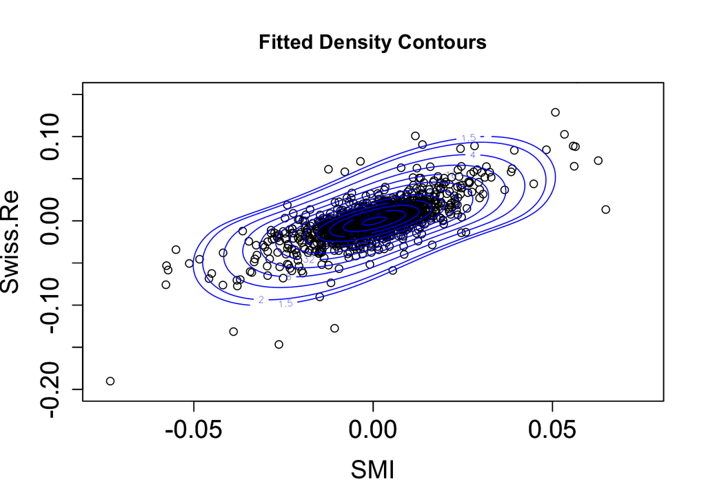

```r
#####################################################################################################################################################
# Contour plots
#####################################################################################################################################################
# Fitted density
pred.den0 <- function(x){
  mu = OPT0$par[1:2]
  sigma = OPT0$par[3:4]
  rho = OPT0$par[7]
  nu = OPT0$par[8]
  nu1 = OPT0$par[5]
  nu2 = OPT0$par[6]
  t.cop = tCopula(rho,dim=2,df=nu)
  prob.t =cbind(pt((x[1]-mu[1])/sigma[1],df=nu1),pt((x[2]-mu[2])/sigma[2],df=nu2))
  var = dCopula(prob.t, copula=t.cop, log=FALSE)*dt((x[1]-mu[1])/sigma[1],df=nu1)*dt((x[2]-mu[2])/sigma[2],df=nu2)/(sigma[1]*sigma[2])
  return(var)
}

# Constructing the grid
x <- (-100:100)/1000
X <- grid2d(x)
z0 <- apply(cbind(X$x,X$y),1,pred.den0)

ZD0 <- list(x = x, y = x, z = matrix(z0, ncol = length(x)))
# Contour Density Plot:
plot(as.vector(Y[,1]),as.vector(Y[,2]),xlim=c(-0.075,0.075),ylim=c(-0.2,0.15), main="Fitted Density Contours",xlab="SMI",ylab="Swiss.Re",cex.axis=1.5,cex.lab=1.5)
par(new=TRUE)
contour(ZD0,levels = c(1.5,2,4,8,16,32,64,128,256,512,1024,2048),xlim=c(-0.075,0.075),ylim=c(-0.2,0.15),col="blue",cex.axis=1.5,cex.lab=1.5)
```